# Przetwarzanie, analiza i wizualizacja danych przestrzennych w języku R

### ggplot2

Pakiet `ggplot2` dla danych rastrowych również przybiera identyczną składnię, a wszystko odbywa się w ramach funkcji `geom_raster()`. Warto mieć na uwadze, że pakiet ten nie akceptuje obiektów *SpatRaster* (tak samo jak *SpatVector*), a ramki danych. W przypadku kiedy definitywnie chcielibyśmy używać obiektów *SpatRaster* bez konwersji, można zainstalować pakiet `tidyterra` i używać funkcji `geom_spatraster()`. W naszym przypadku należy zatem przekonwertować raster do ramki danych, aby był w pełni integrowalny.

W przypadku rastrów należy także zdefiniować długość i szerokość geograficzną pikseli, a więc powinno się wskazać x oraz y, które zostały dodane przy konwersji rastra na ramkę danych.

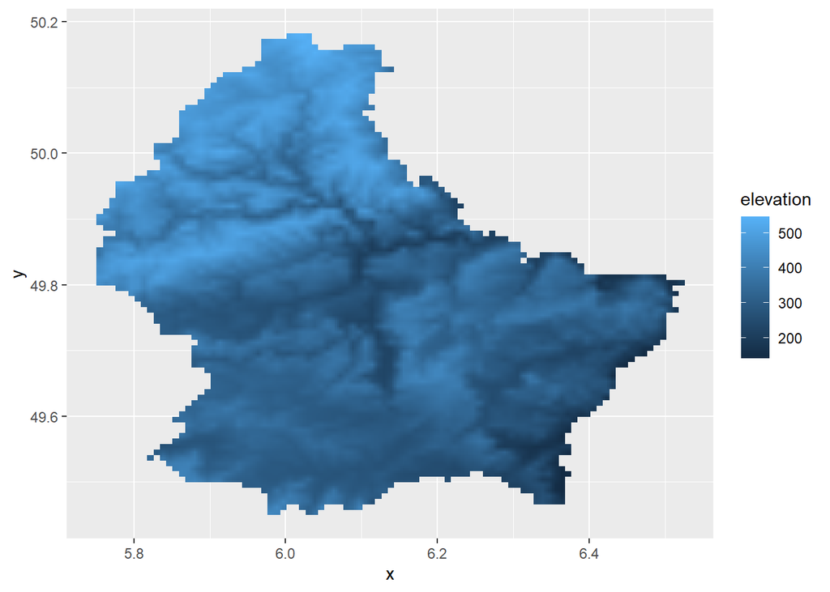

```r
library(ggplot2)

luksemburg_df <- as.data.frame(luksemburg_disagg, xy = TRUE)

ggplot(luksemburg_df, aes(x = x, y = y, fill = elevation)) +
  geom_raster()
```

W odróżnieniu do wizualizacji `tmap`, który odczytuje projekcję danych automatycznie, `ggplot2` traktuje x i y jako zwykłe osie, ignorując projekcję. Dlatego w celu poprawnej wizualizacji często stosuje się funkcję `coord_sf()` ze wskazaniem układu współrzędnych, która koryguje zniekształcenia i utrzymuje poprawną projekcję.

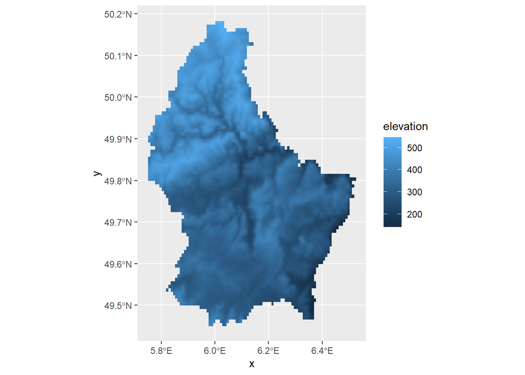

```r
ggplot(luksemburg_df, aes(x = x, y = y, fill = elevation)) +
  geom_raster() + coord_sf(crs = "epsg:4326")
```

Dodatkowe stylizacje warstwy także zachodzą głównie w funkcji `geom_raster()` oraz `theme()`. Pakiet `ggplot2`, który jest powszechniej stosowany do tworzenia wykresów, nie posiada wbudowanych funkcji dodających strzałkę północy lub podziałkę liniową. Elementy te mogą być dodane poprzez funkcje `annotation_scale()` i `annotation_north_arrow()` z pakietu `ggspatial`

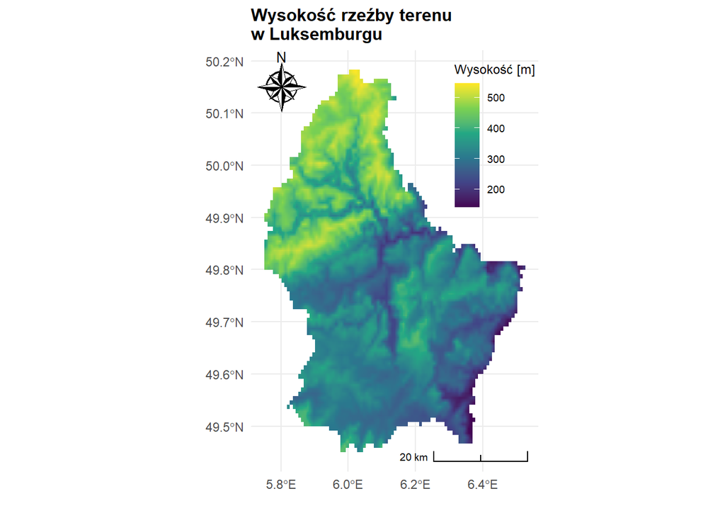

```r
#install.packages("ggspatial")
library(ggspatial)

# Tworzenie wykresu
ggplot(luksemburg_df, aes(x = x, y = y, fill = elevation)) +
  geom_raster() +
  scale_fill_viridis_c(name = "Wysokość [m]", option = "viridis") +
  labs(title = "Wysokość rzeźby terenu\nw Luksemburgu", y = "", x ="") +
  theme_minimal() + coord_sf(crs = "epsg:4326") +
  theme(
    plot.title = element_text(size = 12, face = "bold"),
    legend.position = c(0.85, 0.8),
    legend.title = element_text(size = 9),
    legend.text = element_text(size = 7)
  ) +
  annotation_scale(location = "br", width_hint = 0.4, text_cex = 0.6, style = "ticks") +
  annotation_north_arrow(location = "tl", pad_x = unit(0, "cm"), pad_y = unit(0, "cm"),
                         style = north_arrow_nautical)
```

# Wykresy

Pakiet terra posiada także wbudowane narzędzia do prezentacji wykresów w oparciu o dane rastrowe, bez konieczności konwersji rastrów do wektorów lub ramek danych. Wśród nich znajdują się:

- histogram

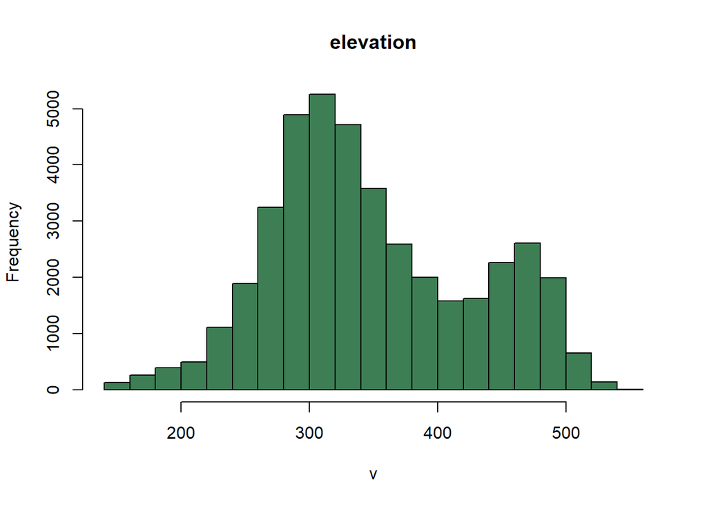

```r
hist(luksemburg_disagg, col = "#3e7e54")
```

- wykres gęstości

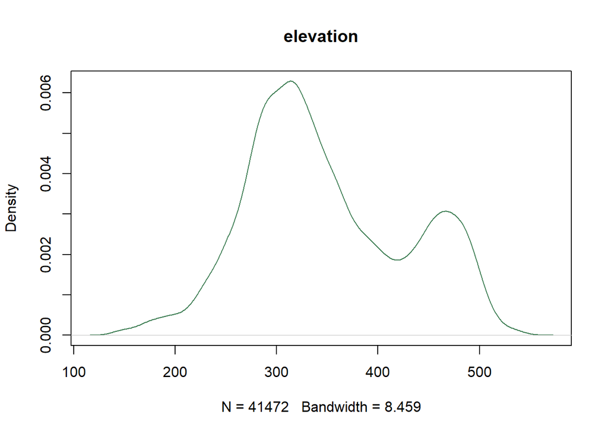

```r
density(luksemburg_disagg, col = "#3e7e54")
```

- wykres pudełkowy

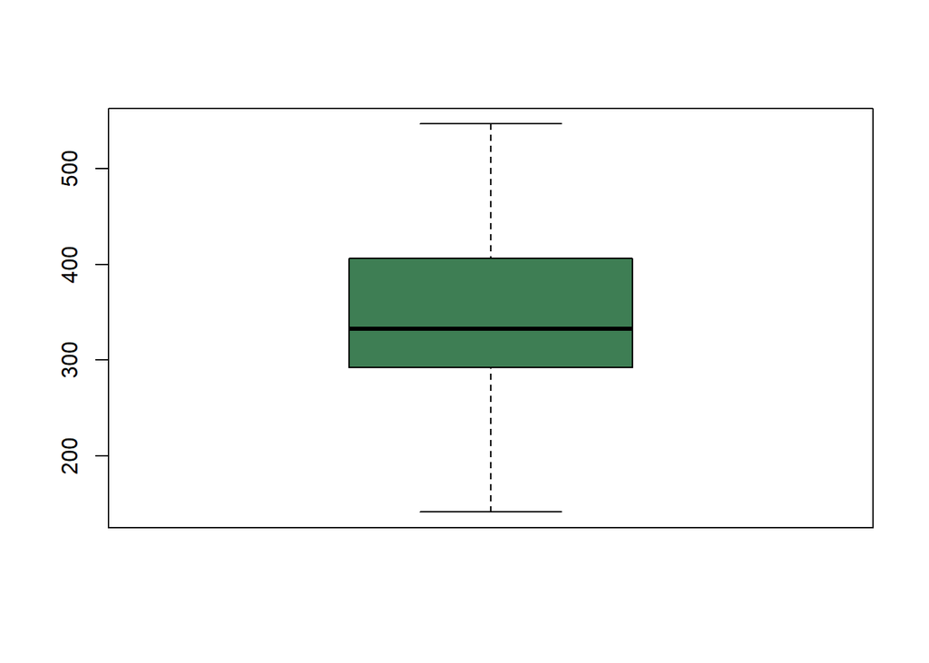

```r
boxplot(luksemburg_disagg, col = "#3e7e54")
```

- wykres par kanałów – przedstawia histogramy, wykres rozrzutu oraz korelację pomiędzy wszystkimi kanałami wybranego rastra

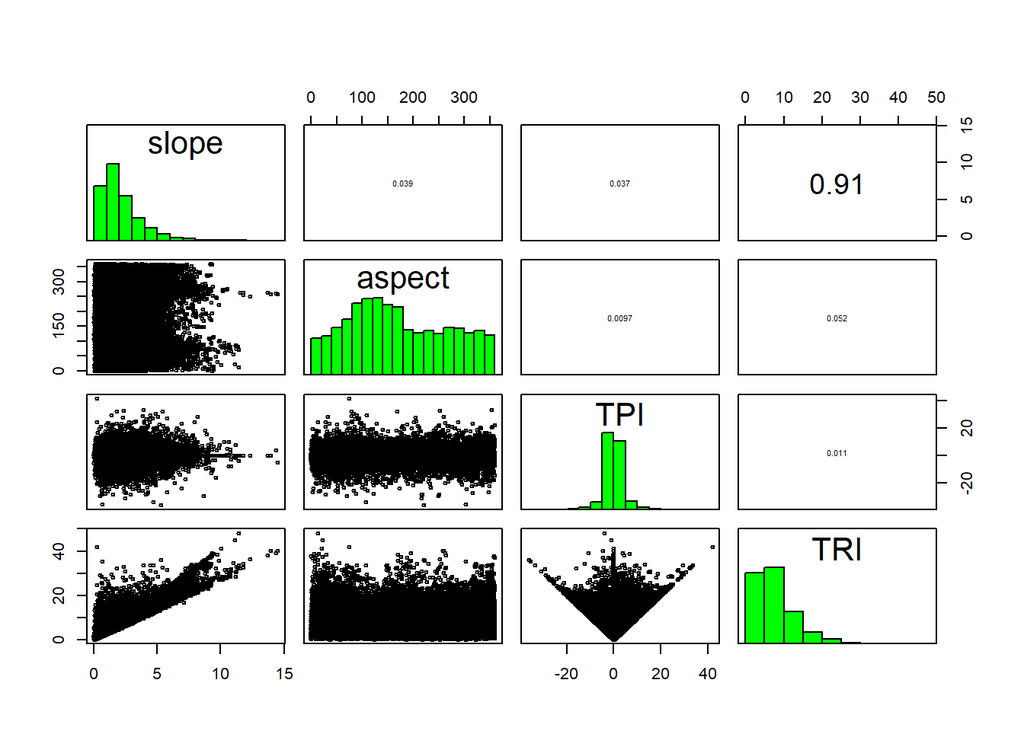

```r
pairs(raster_wielokanalowy, hist=TRUE, cor=TRUE, use="pairwise.complete.obs")
```

# Podsumowanie wiedzy

W oparciu o zdobytą wiedzę o danych rastrowych, poniżej przedstawiono praktyczne zadanie z wykorzystaniem granic jednostek pomocniczych Poznania oraz rastra pokrycia terenu CLC18 (Corine Land Cover 2018).

Pobierz dane ([Link do danych](https://raw.githubusercontent.com/Adrian-Nowacki/kurs_uo/main/dane/04_Rastry/dane.zip)), rozpakuj je, a następnie wykonaj odpowiednie etapy:

Wczytaj dane do dwóch osobnych obiektów, zapoznaj się z ich strukturą, atrybutami i układem współrzędnych. Zmień układ obu warstw na polski.

**Pokaż kod**

```r
library(tidyverse)
library(sf)
library(terra)
library(tmap)
library(ggplot2)

## wczytanie danych
osiedla <- vect("04_Rastry/zadanie/osiedla.gpkg")
clc <- rast("04_Rastry/zadanie/CLC18.tif")

## ujednolicenie układów współrzędnych
osiedla
osiedla <- project(osiedla, "epsg:2180")

clc
clc <- project(clc, "epsg:2180", method = "near")
```

Zaprezentuj dane na prostej mapie, aby zobaczyć ich rozkład przestrzenny. Sprawdź rozdzielczość danych rastrowych, a następnie zmień ją na ok. 10 metrów, aby następnie wykonać dokładniejsze przycięcie do granic Poznania. Pamiętaj o zastosowaniu odpowiedniej metody przekształcenia pikseli rastra, ze względu na dane kategoryczne.

**Pokaż kod**

```r
## wizualizacja
plot(clc)
plot(osiedla, border = "#ffffff", add = TRUE)
```

**Pokaż kod**

```r
# zmiana rozdzielczości
res(clc)
clc_10m <- disagg(clc, fact = 10, method = "near")
res(clc_10m)

# przycięcie do granic Poznania
clc_poznan <- crop(clc_10m, osiedla, mask = TRUE)

plot(clc_poznan)
plot(osiedla, border = "#ffffff", add = TRUE)
```

Sprawdź unikalne kategorie rastra, a następnie skategoryzuj je na podstawie legendy CLC umieszczonej w pliku “legenda_clc.txt” pobranym folderze.

**Pokaż kod**

```r
unique(clc_poznan)

# przypisanie etykiet do odpowiadających wartości
labels <- data.frame(
  value = unique(clc_poznan),
  label = c(
    "Zabudowa miejska zwarta",
    "Zabudowa miejska luźna",
    "Obiekty i tereny przemysłowe lub handlowe",
    "Infrastruktura transportowa",
    "Lotniska",
    "Składowiska odpadów",
    "Tereny zielone w miastach",
    "Tereny rekreacyjno–sportowe",
    "Grunty orne",
    "Łąki i pastwiska",
    "Mozaika użytków rolnych",
    "Użytki rolne z udziałem roślinności naturalnej",
    "Lasy liściaste",
    "Lasy iglaste",
    "Lasy mieszane",
    "Naturalne łąki i pastwiska",
    "Lasy i zarośla w stanie przejściowym",
    "Bagna śródlądowe",
    "Zbiorniki wodne"
  )
)

levels(clc_poznan) <- labels

plot(clc_poznan)
plot(osiedla, border = "#ffffff", add = TRUE)
```

### Mapa powierzchni zabudowy w osiedlach

Z warstwy pokrycia terenu wyodrębnij jedynie te piksele, które oznaczają “Zabudowę miejską luźną”.

**Pokaż kod**

```r
clc_zabudowa <- clc_poznan$label == "Zabudowa miejska luźna"
clc_zabudowa <- mask(clc_zabudowa, clc_zabudowa, maskvalues = FALSE)
plot(clc_zabudowa)
```

W oparciu o wektorowe dane osiedli Poznania wykonaj statystyki strefowe pokrycia terenu, obliczając w ten sposób liczbę pikseli każdej kategorii. Następnie oblicz ich powierzchnię bazując na rozdzielczości piksela. W oparciu o uzyskane wyniki przedstaw w postaci mapy pakietu `tmap` powierzchnię zabudowy miejskiej luźnej w poszczególnych osiedlach – warstwę poligonową osiedli oraz warstwę rastrową samej zabudowy.

**Pokaż kod**

```r
osiedla_stat_strefowe <- terra::zonal(clc_poznan, osiedla, fun = "table", as.polygons=TRUE, na.rm = TRUE)
head(osiedla_stat_strefowe)

# powierzchnia 1 piksela w km2
pow_piksela_km <- (res(clc_poznan)[1] * res(clc_poznan)[2])/1000000

# zamiana na przestrzenną ramkę danych, aby móc przemnożyć wszystkie kolumny
osiedla_stat_strefowe_sf <- as.data.frame(osiedla_stat_strefowe, geom = "WKT")
osiedla_stat_strefowe_sf[, 2:20] <- round(osiedla_stat_strefowe_sf[, 2:20] * pow_piksela_km, 2)

osiedla_stat_strefowe_vect <- vect(osiedla_stat_strefowe_sf, geom = "geometry", crs = "epsg:2180")

mapa_1 <- tm_shape(osiedla_stat_strefowe_vect) +
  tm_polygons(fill = "Zabudowa miejska luźna",
              fill.legend = tm_legend(title = "Powierzchnia zabudowy miejskiej luźnej [km2]"),
              fill.scale = tm_scale_intervals(style = "jenks", values = "Reds")) +
  tm_shape(clc_zabudowa) +
  tm_raster(palette = "#222222", title = "Obszary zabudowy miejskiej luźnej", alpha = 0.3)
```

**Pokaż wynik końcowy**

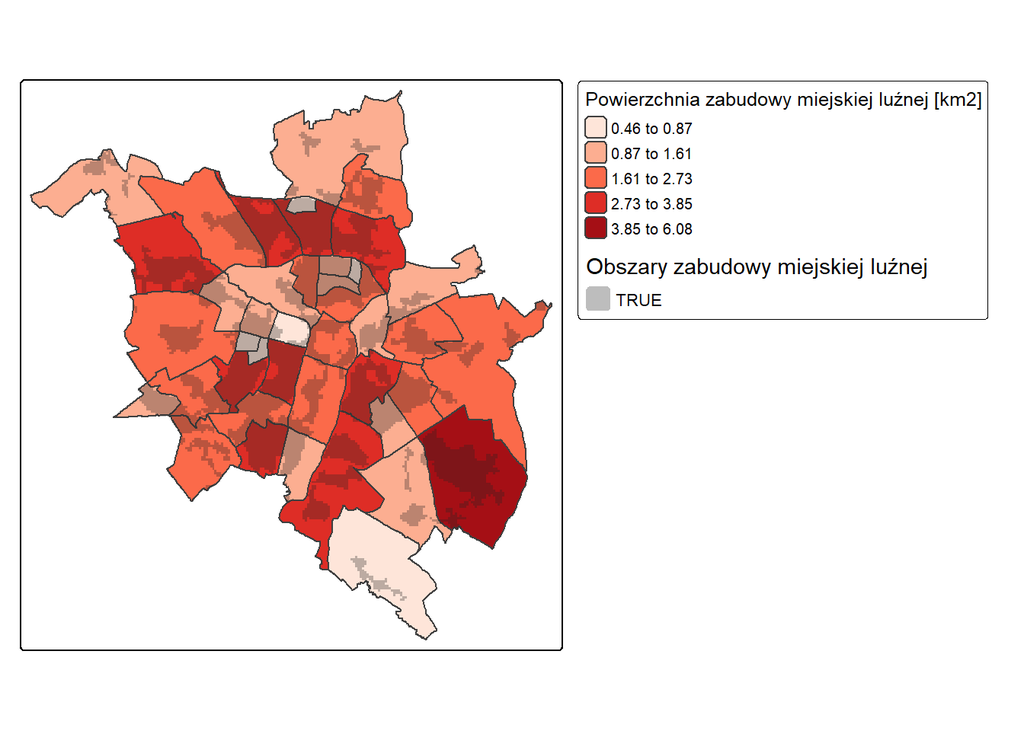

```r
mapa_1
```

### Mapa pokrycia terenu Poznania po reklasyfikacji

Zreklasyfikuj raster pokrycia terenu do 5 głównych klas poziomu 1 – terenów antropogenicznych, rolnych, lasów, obszarów podmokłych oraz obszarów wodnych. Szczegóły kategorii można znaleźć na stronie (https://clc.gios.gov.pl/index.php/o-clc/legenda).

**Pokaż kod**

```r
levels(clc_poznan)
tabela_reklasyfikacji <- matrix(c(1, 11, 1,         # tereny antropogeniczne
                                  11, 21, 2,        # obszary rolne
                                  21, 29, 3,        # lasy
                                  29, 35, 4,        # obszary podmokłe
                                  35, 41, 5),       # obszary wodne
                                  ncol = 3, byrow = TRUE)

clc_poznan_reclass <- classify(clc_poznan, tabela_reklasyfikacji, others = NULL, right = TRUE)
unique(clc_poznan_reclass)
```

W oparciu o uzyskane wyniki przedstaw w postaci mapy pakietu `ggplot2` zreklasyfikowane pokrycie terenu, nadając klasom odpowiednie nazwy i kolory.

**Pokaż kod**

```r
library(ggplot2)

clc_poznan_reclass_df <- as.data.frame(clc_poznan_reclass, xy = TRUE)

# użycie factor() w celu poprawnej wizualizacji danych kategorycznych
mapa_2 <- ggplot(clc_poznan_reclass_df, aes(x = x, y = y, fill = factor(label))) +
  geom_raster() +
 scale_fill_manual(  # użycie scale_fill_manual w celu określenia ręćznych klas
    name = "",
    values = c(
      "1" = "#d73027", "2" = "#fee08b", "3" = "#4a9850", "4" = "#cf7fdb", "5" = "#11c5b4"
    ),
    labels = c(
      "1" = "Tereny antropogeniczne", "2" = "Obszary rolne", "3" = "Lasy i łąki",
      "4" = "Obszary podmokłe", "5" = "Obszary wodne"
    )
  ) +
  labs(title = "Kategorie pokrycia terenu miasta Poznania", y = "", x ="") +
  theme_minimal() + coord_sf(crs = "epsg:2180") +
  theme(
    plot.title = element_text(size = 12, face = "bold"),
    legend.position = "right",
    legend.title = element_text(size = 9),
    legend.text = element_text(size = 7)
  )
```

**Pokaż wynik końcowy**

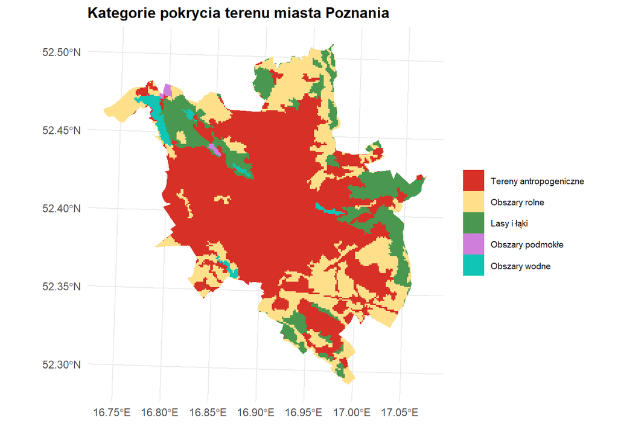

```r
mapa_2
```